# Potus

```python
import polars as pl
import polars.selectors as cs
from cmdstanpy import CmdStanModel
import numpy as np
from scipy.special import logit
from patsy import dmatrices, dmatrix, build_design_matrices, standardize
import matplotlib.pyplot as plt
import seaborn as sns
import arviz as az
```

This post will go over a simplified version of the Economist's model of the 2016 US presidential election.

Let $m_{t, s}$ be the log odds of state $s$ voting democratic if the election were held on day $t$. We'll assume that $m$ obeys a backwards random walk:

$$m_t \sim \mathcal{N}(m_{t+1}, l\ S)$$

Here, $S$ is the state election outcome convariance matrix and $l$ is a lengthscale. On election day $(t=T)$, we give $m_T$ a normal prior centered around the prediction of a linear model using the annualized growth rate of second quarter GDP, the June approval rating of the incumbent, and whether it's the president's second term (Abramowitz's *Time for Change* model). We'll assume that the state-specific deviations from the Abramowitz model at year $y$ will describe the deviations at year $y+1$ too, give and take some Gaussian noise

Here's the associated Stan model:

```python
!cat model.stan
```

```
data {
    int W;
    int Y;
    int F;
    int G;
    matrix[F,4] X;
    vector[F] y;
    row_vector[4] pred_X;
    matrix[51,G] dem_logits;
    vector[F+1] dem_inc;
    matrix[51,51] S;
    int N;
    array[N] int obs_n;
    array[N] int obs_year;
    array[N] int obs_week;
    array[N] int obs_state;
    array[N] int obs_dems;
}
transformed data {
  matrix[51,G] deltas = dem_logits -
    rep_matrix(((2 * dem_inc[F-G+1:F] - 1) .* logit(y[F-G+1:]))', 51);
}
parameters {
    vector[4] beta;
    real<lower=0, upper=1> pred_y;
    array[Y,W] vector[51] steps;
    real<lower=0> l;
    real<lower=0> sigma;
    real<lower=0> delta_sigma;
    vector[51] pred_delta;
}

transformed parameters {
    array[Y, W] vector[51] m;
    m[Y,W] = (2 * dem_inc[F+1] - 1) * pred_y + pred_delta;
    for (p in 1:Y-1) m[Y-p,W] = dem_logits[,G-p+1];
    for (i in 1:(W - 1)) for (p in 1:Y) {
      m[p, W - i] = m[p, W - i + 1] + l * S * steps[p,W - i];
    }
}

model {
    sigma ~ exponential(1 / sd(y));
    l ~ exponential(1);
    delta_sigma ~ exponential(1);
    beta ~ normal(0, sd(y) * 2.5);
    y ~ normal(X * beta, sigma);
    pred_y ~ normal(pred_X * beta, sigma);
    for (p in 1:Y) for (w in 1:W) {
      steps[p,w] ~ std_normal();
    }
    for (i in 1:N) {
      obs_dems[i] ~ binomial_logit(obs_n[i], m[obs_year[i], obs_week[i]][obs_state[i]]);
    }
    for (i in 1:51) {
      deltas[i,2:] ~ normal(deltas[i,:G-1], delta_sigma);
    }
    pred_delta ~ normal(deltas[,G], delta_sigma);
}
```

We can get the growth rate of second quarter GDP and June approval rating from Abramowitz's original dataset.

```python
abramowitz = pl.read_csv("../data/abramowitz_data.csv").sort(
    pl.col("year")).with_columns(incvote = pl.col("incvote") / 100)
```

At first glance, the data certainly seems amenable to a linear fit.

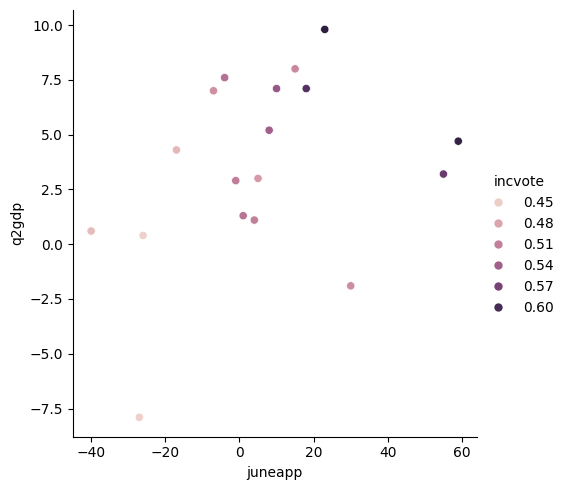

```python
sns.relplot(abramowitz.to_pandas(), x="juneapp", y="q2gdp", hue="incvote");
```

Here's the historical data we'll use for training.

```python
fundamentals_training = abramowitz.filter(pl.col("year") < 2016)
```

```python
y, X = dmatrices("incvote ~ standardize(juneapp) + standardize(q2gdp) + term2", fundamentals_training.to_pandas())
```

And here's the data for the election year we're trying to predict.

```python
pred_X = build_design_matrices([X.design_info], abramowitz.filter(pl.col("year") >= 2016).to_pandas())[0][0]
```

The Abramowitz's model predicts the incumbent's two-party vote share, but the poll data is for democratic vote share. To translate between the two, we need to know whether the incumbent is a democrat.

```python
dem_inc = abramowitz.select(pl.col("deminc")).to_numpy()[:, 0]
```

We'll also need state specific vote totals so we can calculate their deviations from the national model.

```python
state_vote_data = pl.read_csv("../data/potus_results_76_16.csv").filter(pl.col("year") < 2016).select(
    pl.col(["year", "state"]),
    dem_frac= pl.col("dem") / (pl.col("dem") + pl.col("rep"))
).sort(pl.col(["state", "year"]))
```

```python
dem_logits = np.reshape(logit(state_vote_data.select("dem_frac")), (51, -1))
```

From the same dataset, we can find the covariance in state-level swings.

```python
state_vals = state_vote_data.pivot(
    on="state", index="year", values="dem_frac"
).select(pl.col(pl.Float64))
```

To ensure that $S$ is positive definite, I'll add diagonal noise.

```python
S = np.linalg.cholesky(np.cov(state_vals, rowvar=False) + 1e-4 * np.eye(51))
```

Finally, the old HuffPost Pollster website provided a csv file with a collection of state and national polls. As polls are often conducted over a period of several days, we fix the time of a poll as the midpoint between the start and end dates and use week-level granularity for the random walk.

```python
states = pl.Enum(state_vote_data.get_column("state").unique().sort())
```

```python
def prepare_poll_data(data, dem, rep, fmt, year):
    return data.filter(pl.col("state") != "--").with_columns(
        pl.col("^.*date$").str.to_datetime(fmt),
        total_votes = (pl.col("number.of.observations") * ((pl.col(dem) + pl.col(rep)) / 100)).round().cast(pl.Int32),
    ).select(
        pl.col(["total_votes", "start.date", "end.date"]),
        week=(pl.col("start.date") + ((pl.col("end.date") - pl.col("start.date")) / 2)).dt.week(),
        state=pl.col("state").cast(states),
        election_year=year,
        dem_votes= (pl.col("total_votes") * (pl.col(dem) / (pl.col(dem) + pl.col(rep)))).round().cast(pl.Int32)
    )
```

```python
poll_data = pl.concat([
    prepare_poll_data(pl.read_csv('../data/all_polls_2008.csv', infer_schema_length=10000), "obama", "mccain", "%m/%d/%y", 1),
    prepare_poll_data(pl.read_csv('../data/all_polls_2012.csv', infer_schema_length=10000), "obama", "romney", "%m/%d/%y", 2),
    prepare_poll_data(pl.read_csv('../data/all_polls.csv').with_columns(
        pl.col("number.of.observations").str.to_integer(strict=False).drop_nans()), "clinton", "trump", "%Y-%m-%d", 3)
]).drop_nulls()
```

```python
poll_data.group_by(pl.col("election_year")).agg(min=pl.col("start.date").min(), max=pl.col("start.date").max())
```

shape: (3, 3)

| election_year i32 | min datetime[μs] | max datetime[μs] |
| --- | --- | --- |
| 1 | 2008-01-04 00:00:00 | 2008-10-31 00:00:00 |
| 2 | 2012-02-27 00:00:00 | 2012-11-05 00:00:00 |
| 3 | 2015-06-18 00:00:00 | 2016-11-06 00:00:00 |

We'll focus on the last 10 weeks to keep inference fast.

```python
poll_data = poll_data.filter(pl.col("week") > 40)
```

We need to reindex the weeks from 1 to work with Stan's indexing.

```python
poll_data = poll_data.with_columns(week=pl.col("week") - pl.col("week").min() + 1)
```

It remains to run the model.

```python
data = {
    "obs_week": poll_data.get_column("week").to_numpy(),
    "obs_year": poll_data.get_column("election_year").to_numpy(),
    "obs_dems": poll_data.get_column("dem_votes").to_numpy(),
    "obs_state": poll_data.get_column("state").to_physical().to_numpy() + 1,
    "obs_n": poll_data.get_column("total_votes").to_numpy(),
    "N": poll_data.shape[0],
    "S": S,
    "dem_inc": dem_inc,
    "dem_logits": dem_logits,
    "X": np.asarray(X),
    "pred_X": np.asarray(pred_X),
    "y": np.asarray(y)[:,0],
    "W": poll_data.get_column("week").max(),
    "Y": 3,
    "F": X.shape[0],
    "G": dem_logits.shape[1]
}
```

```python
model = CmdStanModel(stan_file="model.stan", cpp_options={'STAN_THREADS':'true'})
```

```
22:00:41 - cmdstanpy - INFO - compiling stan file /Users/sam/Desktop/us-potus-model/simplified/model.stan to exe file /Users/sam/Desktop/us-potus-model/simplified/model
22:00:47 - cmdstanpy - INFO - compiled model executable: /Users/sam/Desktop/us-potus-model/simplified/model
```

```python
fit = model.sample(data=data)
```

```
22:00:55 - cmdstanpy - INFO - CmdStan start processing
```

```
chain 1 |          | 00:00 Status
```

```
chain 2 |          | 00:00 Status
```

```
chain 3 |          | 00:00 Status
```

```
chain 4 |          | 00:00 Status
```

[output not shown]

We can see the effect of polling by tracking the uncertainty around the value of $m$ for heavily polled states. The most heavily polled state is Florida.

```python
poll_data.group_by("state").agg(count=pl.len()).sort("count", descending=True).head()
```

shape: (5, 2)

| state enum | count u32 |
| --- | --- |
| "FL" | 109 |
| "OH" | 103 |
| "NC" | 83 |
| "VA" | 81 |
| "PA" | 73 |

Below, we plot Florida's value of $m$ over time for 2012 and 2016. A grey background is drawn when polls were conducted.

```python
m = fit.stan_variable("m")
```

Here's the data for 2012. We know the eventual outcome of the vote, so our uncertainty is low for the last week.

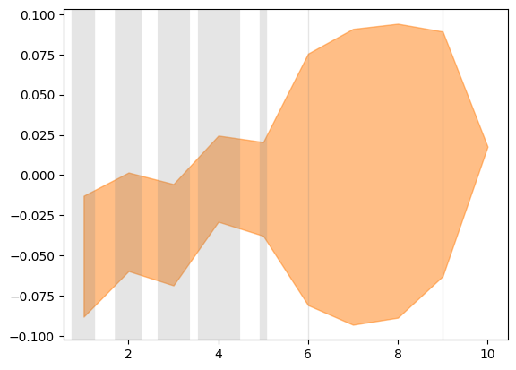

```python
az.plot_hdi(1 + np.arange(10), m[None,:, 1, :, list(states.categories).index('FL')], smooth=False)
for (w,l) in poll_data.filter(pl.col("state") == "FL").group_by("week").agg(pl.len()).iter_rows():
    plt.axvline(x=w, c='grey', linewidth=l, alpha=0.2)
```

For 2016, the random walk shows our uncertain prediction of how Florida would vote:

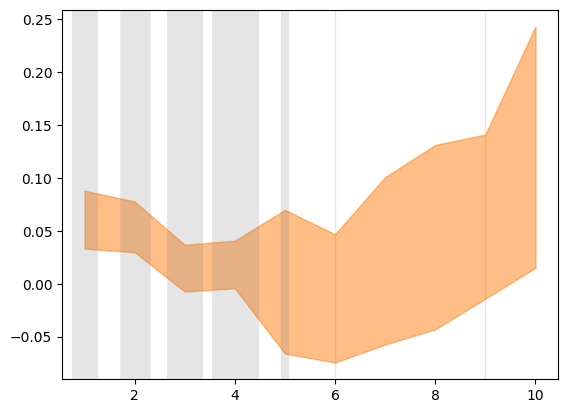

```python
az.plot_hdi(1 + np.arange(10), m[None,:, 2, :, list(states.categories).index('FL')], smooth=False)
for (w,l) in poll_data.filter(pl.col("state") == "FL").group_by("week").agg(pl.len()).iter_rows():
    plt.axvline(x=w, c='grey', linewidth=l, alpha=0.2)
```

We can see the quality of our model by sampling ficticious poll data from the posterior predictive distribution. The distribution over posterior predictive samples looks quite similar to what we observed.

```python
inf1 = az.from_cmdstanpy(posterior=fit, observed_data=data,  posterior_predictive="obs_hat")
```

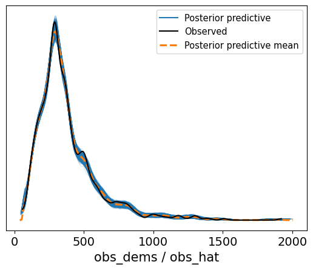

```python
az.plot_ppc(inf1, data_pairs = {'obs_dems' : 'obs_hat'}, var_names='obs_dems');
```

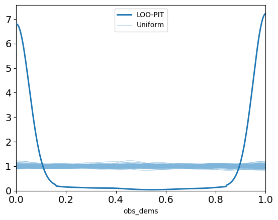

```python
az.plot_loo_pit(inf1, y="obs_dems", y_hat="obs_hat")
```